```r
cutoff
```

```
## [1] 56.89229
```

```r
#exclude outliers
noout<- subset(nomiss,mahal < cutoff)
nrow(noout)
```

```
## [1] 338
```

assess correlation. Items that are too correlated should be examined for removal.

```r
#additivity
correl<- cor(noout, use = "pairwise.complete.obs")
symnum(correl)
```

```
##      R1 R2 R3 R4 R5 R6 E1 E2 E3 E4 E5 E6 E7 T1 T2 T3 T4 T5 P5 P1 P2 P3 P4 B5 B1
## Rel1 1
## Rel2 ,  1
## Rel3 ,  .  1
## Rel4 .  .  ,  1
## Rel5 ,  .  .  .  1
## Rel6 .  .  ,  .  .  1
## Env1       .           1
## Env2       .  .           1
## Env3 .  .  .  .  .     .  .  1
## Env4 .     .  .  .  .  .  .  ,  1
## Env5 .  .  .  .  .  .  .     ,  ,  1
## Env6 .  .  .  .  .  .  .  .  .  ,  ,  1
## Env7 .  .  .  .  .  .  .  .  .  .  ,  ,  1
## Tx1  .  .  .  .  .  .  .  .  .  .  .  .  .  1
## Tx2  .  .  .  .  .  .  .  .  .  .  .  .  .  .  1
## Tx3  .  .  .  .  .  .  .  .  .  .  .  .  .  ,  .  1
## Tx4  .  .  .  .  .  .  .     .  .  .  .  .  .  .  .  1
## Tx5  .  .  .  .  .  ,        .     .  .  .  ,  .  ,  .  1
## Po5  .  .  .  .  .  .     .  .  .  .  .  .  .  .  .  .  .  1
## Po1  .     .  .  .  .  .  .  .  .  .  .  .  .  .  .  .     .  1
## Po2  .  .  .  .  .  .     .     .  .  .  .  .  .  .  .  .  .  .  1
## Po3        .  .  .  .  .  .  .  .  .  .  .  .  .  .  .  .  .  .  .  1
## Po4  .  .  .  .  .  .  .     .  .  ,  ,  ,  .  .  .  .  .  .  .  .  .  1
## Bn5           .        .     .  .  .  .  .                 .  .     .  .  1
## Bn1  .     .  .  .  .  .           .  .     .  .  .  .  .     .  .     .     1
## Bn2        .           .                       .  .           .     .     .
## Bn3           .           .                    .           .  .     .     .
## Bn4  .  .  .  .  .  .  .  .  .  .  .  .  .  .  .  .  .  .  .  .  .  .  .     .
##      B2 B3 B4
## Rel1
## Rel2
## Rel3
## Rel4
## Rel5
## Rel6
## Env1
## Env2
## Env3
## Env4
## Env5
## Env6
## Env7
## Tx1
## Tx2
## Tx3
## Tx4
## Tx5
## Po5
## Po1
## Po2
## Po3
## Po4
## Bn5
## Bn1
## Bn2  1
## Bn3  .  1
## Bn4        1
## attr(,"legend")
## [1] 0 ' ' 0.3 '.' 0.6 ',' 0.8 '+' 0.9 '*' 0.95 'B' 1
```

performing a factor analysis requires us to make certain assumptions about the distribution of the data. We check our assumptions by comparing against a random variable

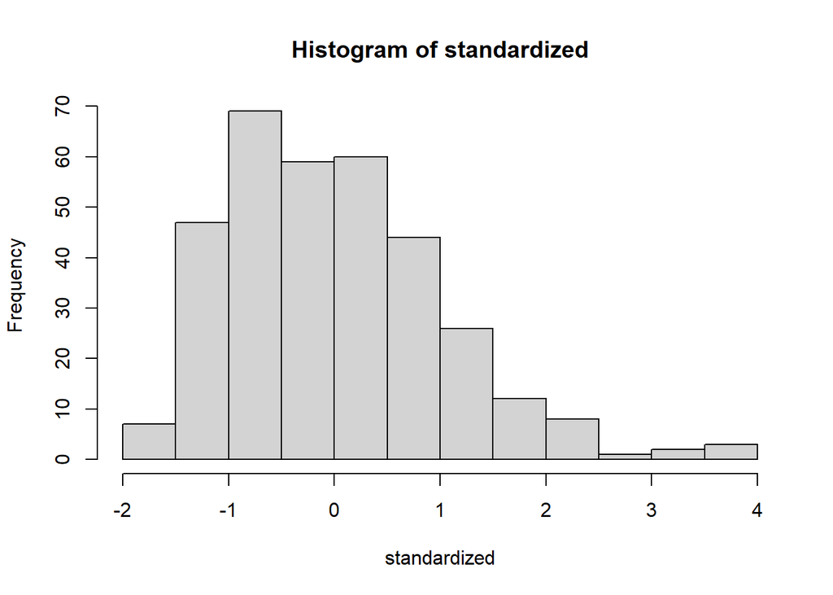

```r
#assumption set up
#make a random variable
random<- rchisq(nrow(noout),5)
fake<- lm(random~., data = noout)
standardized<- rstudent(fake)
fitted<- scale(fake$fitted.values)

#normality
hist(standardized)
```

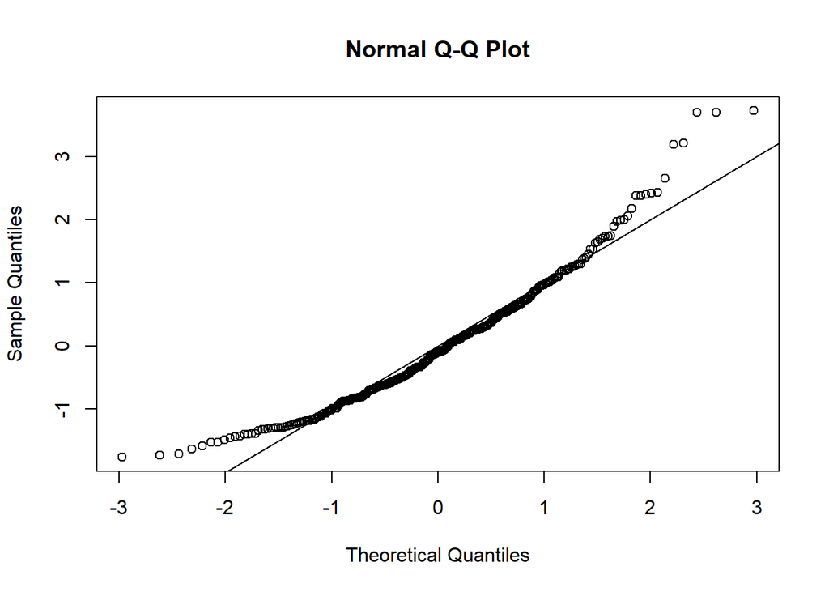

```r
#linearity
qqnorm(standardized)
abline(0,1)
```

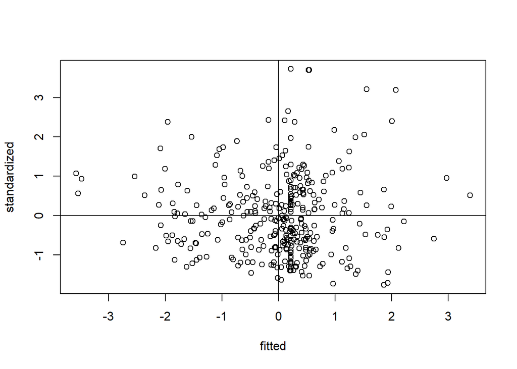

```r
#homogeneity
plot(fitted,standardized)
abline(0,0)
abline(v=0)
```

```r
#correlation adequacy #yes is adequare bc p value is 0
cortest.bartlett(correl, n=nrow(noout))
```

```
## $chisq
## [1] 5300.586
##
## $p.value
## [1] 0
##
## $df
## [1] 378
```

```r
#sampling adequacy #MSA >= 0.7
KMO(correl)
```

```
## Kaiser-Meyer-Olkin factor adequacy
## Call: KMO(r = correl)
## Overall MSA =  0.94
## MSA for each item =
## Rel1 Rel2 Rel3 Rel4 Rel5 Rel6 Env1 Env2 Env3 Env4 Env5 Env6 Env7  Tx1  Tx2  Tx3
## 0.89 0.91 0.95 0.96 0.97 0.94 0.93 0.93 0.94 0.92 0.93 0.92 0.91 0.95 0.97 0.95
##  Tx4  Tx5  Po5  Po1  Po2  Po3  Po4  Bn5  Bn1  Bn2  Bn3  Bn4
## 0.96 0.92 0.96 0.94 0.97 0.96 0.95 0.92 0.93 0.92 0.92 0.96
```

```r
#Our hypothesis was 5 factors
# parallel analysis and scree

nofactors<- fa.parallel(noout,fm="ml",fa="fa")
sum(nofactors$fa.values>1.0)
sum(nofactors$fa.values>0.7)
```

[output not shown]

## This EFA indicates a 4 factor model. We perform EFA with oblique rotation. Results are bests formatted in excel. Items are examined for factor loadings >0.4.

```
## Factor Analysis using method =  ml
## Call: fa(r = noout, nfactors = 4, rotate = "oblimin", fm = "ml")
## Standardized loadings (pattern matrix) based upon correlation matrix
##        ML1   ML3   ML2   ML4   h2   u2 com
## Rel1  0.09 -0.04  0.90 -0.05 0.81 0.19 1.0
## Rel2 -0.06 -0.02  0.86  0.07 0.71 0.29 1.0
## Rel3  0.05  0.34  0.48  0.12 0.65 0.35 2.0
## Rel4  0.01  0.18  0.51  0.18 0.53 0.47 1.5
## Rel5  0.26  0.22  0.42 -0.04 0.53 0.47 2.2
## Rel6  0.03  0.46  0.42 -0.04 0.59 0.41 2.0
## Env1  0.22  0.11 -0.03  0.34 0.30 0.70 2.0
## Env2  0.11  0.15  0.00  0.40 0.30 0.70 1.4
## Env3  0.70 -0.02 -0.02  0.08 0.52 0.48 1.0
## Env4  0.80 -0.10  0.03  0.01 0.60 0.40 1.0
## Env5  0.83 -0.06  0.08 -0.04 0.67 0.33 1.0
## Env6  0.77  0.05 -0.02  0.04 0.66 0.34 1.0
## Env7  0.74  0.20 -0.06  0.00 0.68 0.32 1.2
## Tx1   0.07  0.74 -0.05  0.07 0.61 0.39 1.0
## Tx2   0.17  0.21  0.12  0.33 0.42 0.58 2.6
## Tx3   0.09  0.69  0.02  0.13 0.67 0.33 1.1
## Tx4   0.24  0.45  0.11 -0.01 0.46 0.54 1.6
## Tx5  -0.02  0.85  0.06 -0.06 0.72 0.28 1.0
## Po5   0.21  0.06  0.23  0.26 0.36 0.64 3.1
## Po1   0.26  0.00  0.03  0.50 0.48 0.52 1.5
## Po2   0.05  0.31  0.28  0.19 0.43 0.57 2.7
## Po3   0.17  0.33 -0.06  0.37 0.45 0.55 2.5
## Po4   0.60  0.12  0.09  0.07 0.60 0.40 1.2
## Bn5   0.15 -0.16  0.05  0.60 0.42 0.58 1.3
## Bn1   0.09  0.26  0.12  0.17 0.25 0.75 2.5
## Bn2  -0.11  0.21  0.02  0.52 0.34 0.66 1.4
## Bn3  -0.07 -0.03  0.04  0.71 0.46 0.54 1.0
## Bn4   0.26  0.29  0.19  0.08 0.44 0.56 2.9
##
##                        ML1  ML3  ML2  ML4
## SS loadings           4.65 3.86 3.35 2.80
## Proportion Var        0.17 0.14 0.12 0.10
## Cumulative Var        0.17 0.30 0.42 0.52
## Proportion Explained  0.32 0.26 0.23 0.19
## Cumulative Proportion 0.32 0.58 0.81 1.00
##
```

[output cut: 13 more lines]

```
## The root mean square of the residuals (RMSR) is  0.03
## The df corrected root mean square of the residuals is  0.04
##
## The harmonic number of observations is  338 with the empirical chi square  230.68  with prob <  0.97
## The total number of observations was  338  with Likelihood Chi Square =  525.66  with prob <  2.5e-18
##
## Tucker Lewis Index of factoring reliability =  0.928
## RMSEA index =  0.052  and the 90 % confidence intervals are  0.046 0.059
## BIC =  -1058.21
## Fit based upon off diagonal values = 0.99
## Measures of factor score adequacy
##                                                    ML1  ML3  ML2  ML4
## Correlation of (regression) scores with factors   0.96 0.94 0.95 0.90
## Multiple R square of scores with factors          0.91 0.89 0.91 0.80
## Minimum correlation of possible factor scores     0.83 0.78 0.81 0.61
```

EFA source code credit to StatisticsofDoom on YT :)